# Maternal Smoking and Birth Weights

Prajwal Vijendra

September 26, 2018

Our questions of interest include the following.

Do mothers who smoke tend to give birth to babies with lower weights than mothers who do not smoke? What is a likely range for the difference in birth weights for smokers and non-smokers?

Is there any evidence that the association between smoking and birth weight differs by mother’s race? If so, characterize those differences.

Are there other interesting associations with birth weight with any other variable that are worth mentioning?

Loading the dataset

```r
library(tidyverse)
library(lattice)

babies_df <-  read.csv("./Dataset/smoking.csv")

head(babies_df)
```

```
##     id date gestation bwt.oz parity mrace mage med mht mpregwt inc smoke
## 1 4604 1598       148    116      7     7   28   1  66     135   2     0
## 2 7435 1527       181    110      7     7   27   1  64     133   1     0
## 3 7722 1563       204     55     11     7   35   3  65     140   6     0
## 4 2026 1503       225    132      4     7   28   2  67     148   3     0
## 5 3553 1638       233    105      4     7   34   3  61     130   3     0
## 6 3491 1705       234     85      7     7   33   1  67     130   2     0
```

```r
summary(babies_df)
```

```
##        id            date        gestation         bwt.oz
##  Min.   :  15   Min.   :1350   Min.   :148.0   Min.   : 55.0
##  1st Qu.:5477   1st Qu.:1444   1st Qu.:272.0   1st Qu.:108.0
##  Median :6734   Median :1540   Median :279.0   Median :119.0
##  Mean   :6032   Mean   :1536   Mean   :278.5   Mean   :118.4
##  3rd Qu.:7587   3rd Qu.:1627   3rd Qu.:286.0   3rd Qu.:129.0
##  Max.   :9263   Max.   :1714   Max.   :338.0   Max.   :174.0
##      parity           mrace            mage            med
##  Min.   : 0.000   Min.   :0.000   Min.   :15.00   Min.   :0.000
##  1st Qu.: 1.000   1st Qu.:0.000   1st Qu.:23.00   1st Qu.:2.000
##  Median : 2.000   Median :2.000   Median :26.00   Median :2.000
##  Mean   : 1.953   Mean   :2.995   Mean   :27.29   Mean   :2.932
##  3rd Qu.: 3.000   3rd Qu.:7.000   3rd Qu.:31.00   3rd Qu.:4.000
##  Max.   :11.000   Max.   :9.000   Max.   :45.00   Max.   :7.000
##       mht           mpregwt           inc            smoke
##  Min.   :53.00   Min.   : 87.0   Min.   :0.000   Min.   :0.0000
##  1st Qu.:62.00   1st Qu.:113.0   1st Qu.:2.000   1st Qu.:0.0000
##  Median :64.00   Median :125.0   Median :3.000   Median :0.0000
##  Mean   :64.07   Mean   :128.5   Mean   :3.681   Mean   :0.4638
##  3rd Qu.:66.00   3rd Qu.:140.0   3rd Qu.:5.000   3rd Qu.:1.0000
##  Max.   :72.00   Max.   :220.0   Max.   :9.000   Max.   :1.0000
```

Collapsing the mother’s race categories from 0 to 5 to one category.

Collapsing mothers who smoke or have smoked into one categories.

```r
babies_df$mrace[babies_df$mrace ==0 | babies_df$mrace ==1 | babies_df$mrace ==2 | babies_df$mrace ==3 | babies_df$mrace ==4 | babies_df$mrace ==5] = 5

babies_df$smoke[babies_df$smoke ==1 | babies_df$smoke ==2 | babies_df$smoke == 3] = 1
```

Plotting the scatter & box plots for baby weight against all the independent variable.

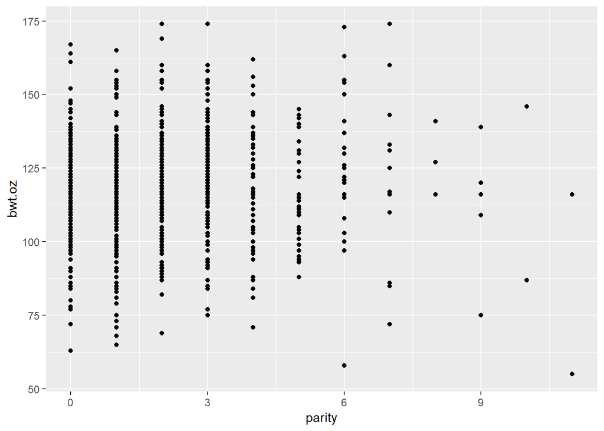

```r
ggplot(data = babies_df) + geom_point(mapping = aes(x = parity, y = bwt.oz))
```

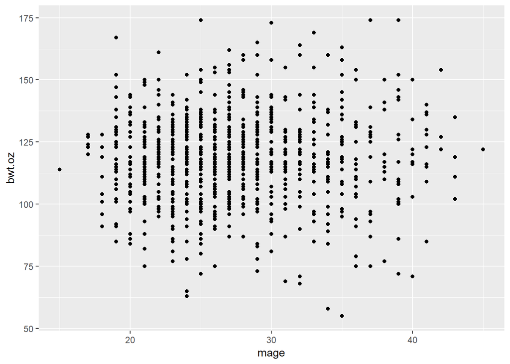

```r
ggplot(data = babies_df) + geom_point(mapping = aes(x = mage, y = bwt.oz))
```

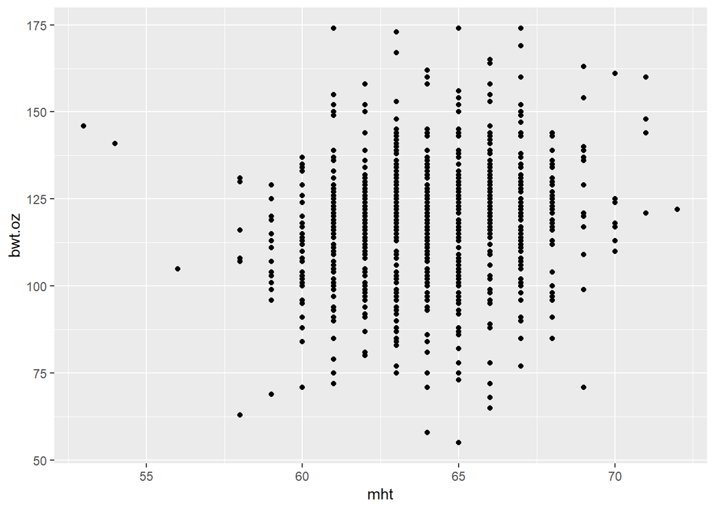

```r
ggplot(data = babies_df) + geom_point(mapping = aes(x = mht, y = bwt.oz))
```

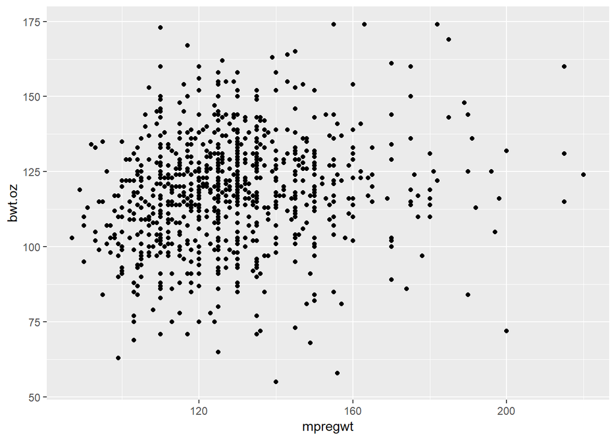

```r
ggplot(data = babies_df) + geom_point(mapping = aes(x = mpregwt, y = bwt.oz))
```

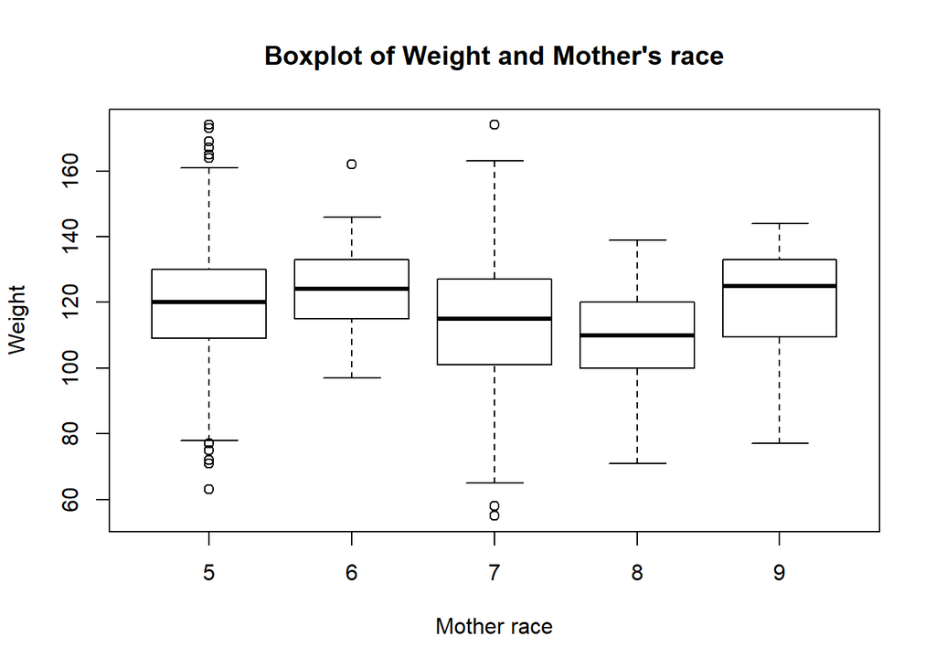

```r
boxplot(bwt.oz~mrace, data = babies_df, xlab = "Mother race", ylab = "Weight", main = "Boxplot of Weight and Mother's race")
```

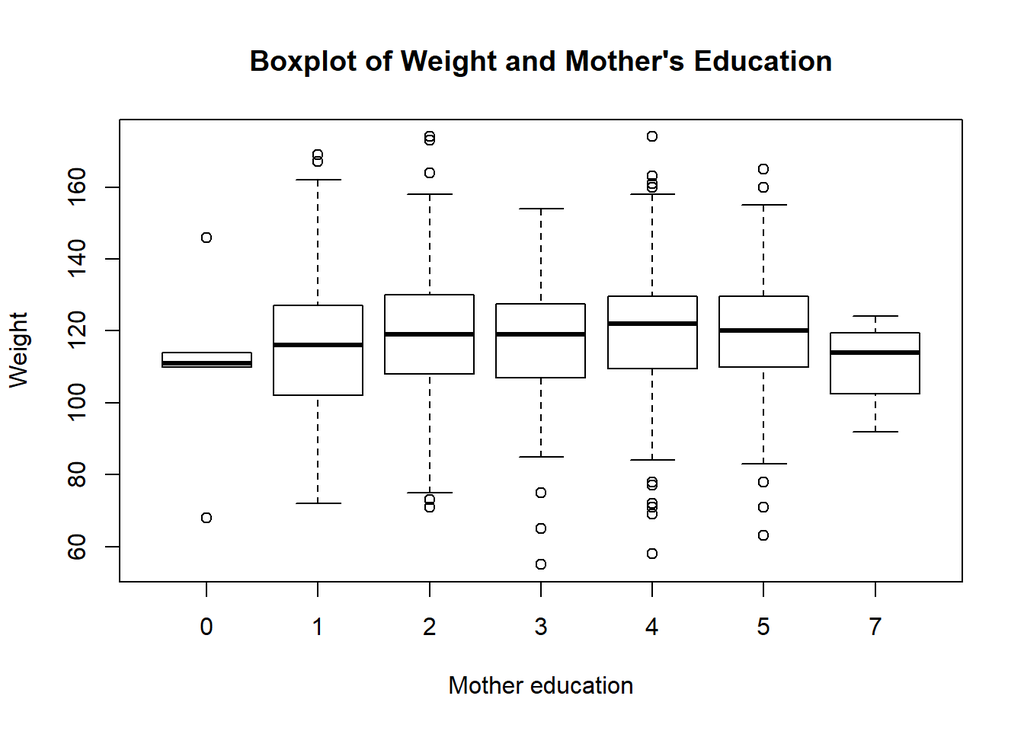

```r
boxplot(bwt.oz~med, data = babies_df, xlab = "Mother education", ylab = "Weight", main = "Boxplot of Weight and Mother's Education")
```

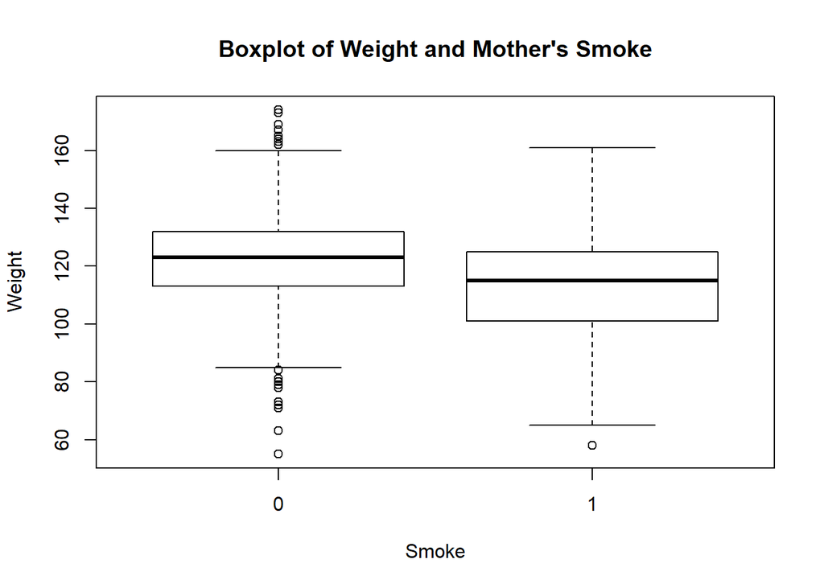

```r
boxplot(bwt.oz~smoke, data = babies_df, xlab = "Smoke", ylab = "Weight", main = "Boxplot of Weight and Mother's Smoke")
```

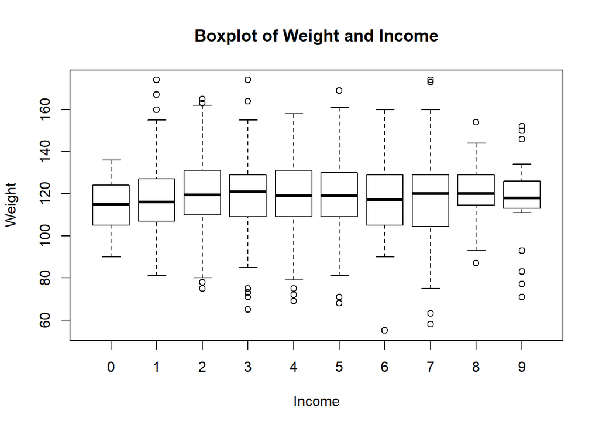

```r
boxplot(bwt.oz~inc, data = babies_df, xlab = "Income", ylab = "Weight", main = "Boxplot of Weight and Income")
```

The scatter and box plot looks ordinary. Nothing remarkable. Most of the plots show a linear realtion with a wide spread. The box plot for mother’s education shows slight variance. We can try by taking the log transformation of mother’s education

Lets check for multicollinearity between the independent variables.

```r
cor(babies_df)
```

```
##                    id        date   gestation       bwt.oz       parity
## id         1.00000000  0.23942033  0.05232511 -0.047257268 -0.161658495
## date       0.23942033  1.00000000  0.06453219  0.091575246  0.079779084
## gestation  0.05232511  0.06453219  1.00000000  0.394915002 -0.132691193
## bwt.oz    -0.04725727  0.09157525  0.39491500  1.000000000  0.041069517
## parity    -0.16165850  0.07977908 -0.13269119  0.041069517  1.000000000
## mrace      0.01962886  0.03135512 -0.15509648 -0.148682116  0.156040958
## mage       0.02405103  0.06461615 -0.03070037  0.044343562  0.523690421
## med       -0.03209292 -0.06621575  0.06422055  0.038331516 -0.201009718
## mht       -0.03838623 -0.06641239  0.06072598  0.187758035 -0.042815618
## mpregwt   -0.07603560  0.02451147  0.06866846  0.182115783  0.150537887
## inc        0.06910438  0.06746243  0.02728892  0.002172599  0.009361419
## smoke     -0.01527633 -0.07850980 -0.05831662 -0.249063159  0.011060808
##                 mrace         mage         med          mht      mpregwt
## id         0.01962886  0.024051034 -0.03209292 -0.038386234 -0.076035601
## date       0.03135512  0.064616147 -0.06621575 -0.066412386  0.024511469
## gestation -0.15509648 -0.030700374  0.06422055  0.060725976  0.068668464
## bwt.oz    -0.14868212  0.044343562  0.03833152  0.187758035  0.182115783
## parity     0.15604096  0.523690421 -0.20100972 -0.042815618  0.150537887
## mrace      1.00000000  0.038093001 -0.01890512 -0.151241687  0.039196391
## mage       0.03809300  1.000000000  0.13404421 -0.005470885  0.146136818
## med       -0.01890512  0.134044215  1.00000000  0.115443861 -0.053849809
## mht       -0.15124169 -0.005470885  0.11544386  1.000000000  0.460446304
## mpregwt    0.03919639  0.146136818 -0.05384981  0.460446304  1.000000000
## inc       -0.11335070  0.296621172  0.21667845  0.071476505 -0.005130309
## smoke     -0.10812655 -0.069865661 -0.13788464  0.041168187 -0.048550583
##                    inc        smoke
## id         0.069104380 -0.015276327
## date       0.067462425 -0.078509798
## gestation  0.027288918 -0.058316625
## bwt.oz     0.002172599 -0.249063159
## parity     0.009361419  0.011060808
## mrace     -0.113350695 -0.108126554
## mage       0.296621172 -0.069865661
## med        0.216678451 -0.137884639
## mht        0.071476505  0.041168187
## mpregwt   -0.005130309 -0.048550583
## inc        1.000000000  0.006527649
## smoke      0.006527649  1.000000000
```

Collinearity table doesn’t show high collinearity between the varaiables. The highest collinearity in the table is between mage and parity (0.52).

Since, the highest collinearity is 0.52, We can safely conclude there is no multicollinearity.

Let us check for interactions:

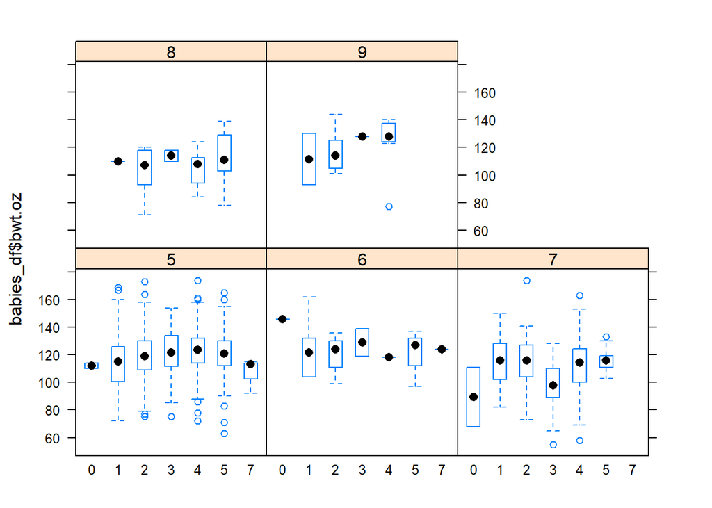

```r
bwplot(babies_df$bwt.oz~ as.factor(babies_df$med) | as.factor(babies_df$mrace))
```

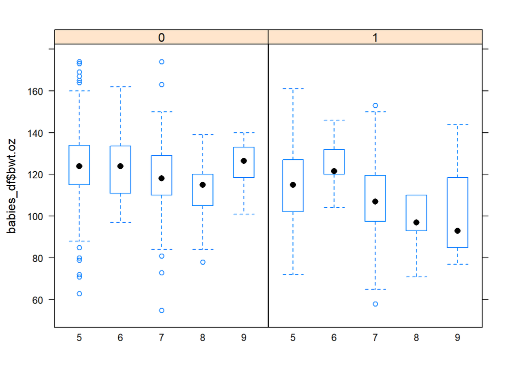

```r
bwplot(babies_df$bwt.oz~as.factor(babies_df$mrace) | as.factor(babies_df$smoke))
```

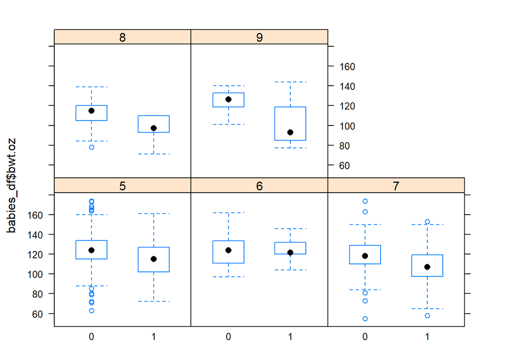

```r
bwplot(babies_df$bwt.oz~as.factor(babies_df$smoke) | as.factor(babies_df$mrace))
```

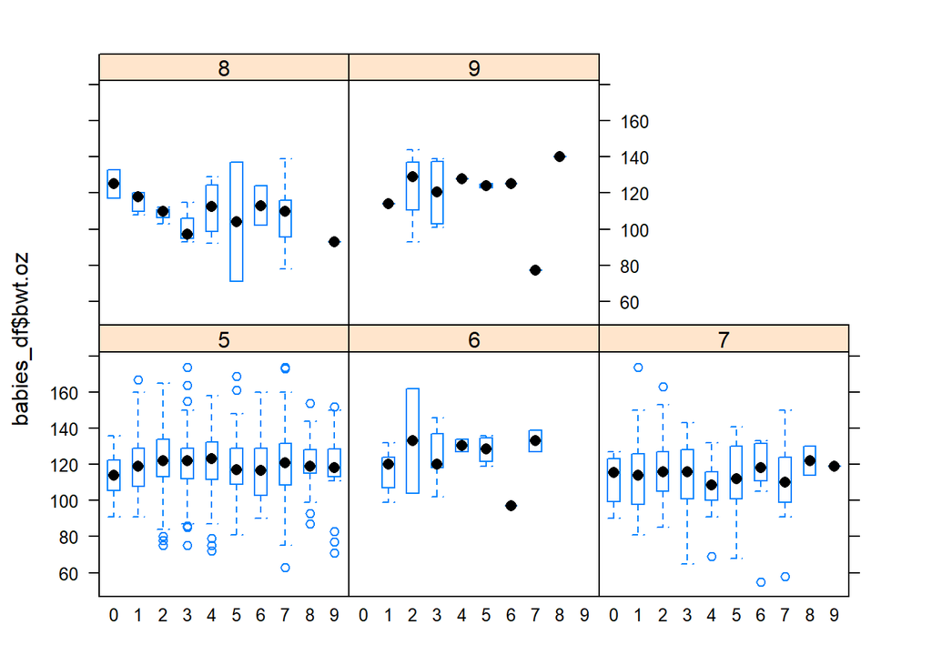

```r
bwplot(babies_df$bwt.oz~ as.factor(babies_df$inc) | as.factor(babies_df$mrace))
```

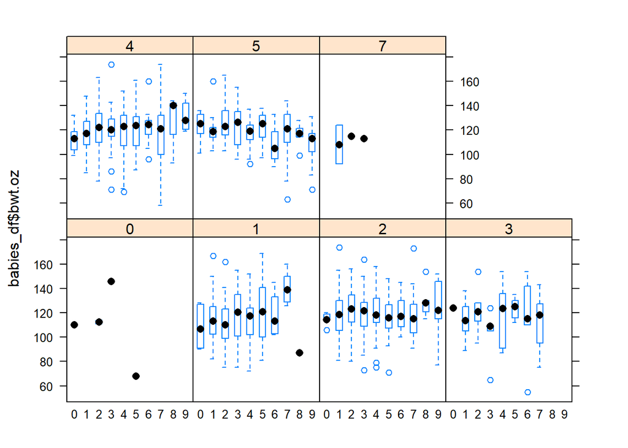

```r
bwplot(babies_df$bwt.oz~ as.factor(babies_df$inc) | as.factor(babies_df$med))
```

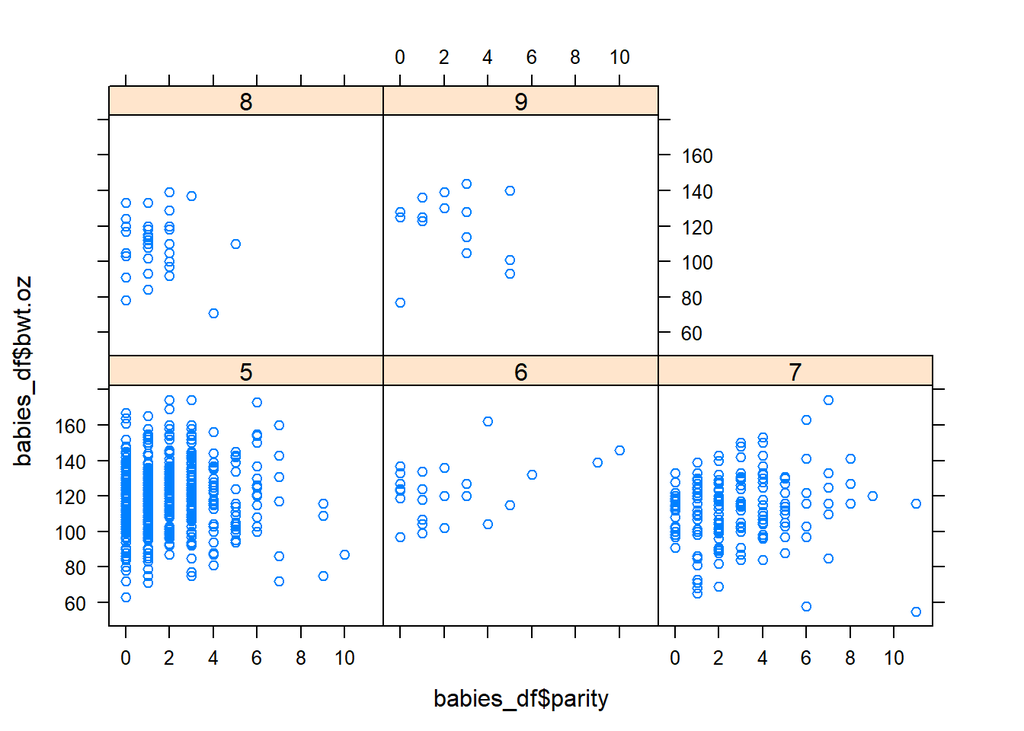

```r
xyplot(babies_df$bwt.oz~babies_df$parity | as.factor(babies_df$mrace))
```

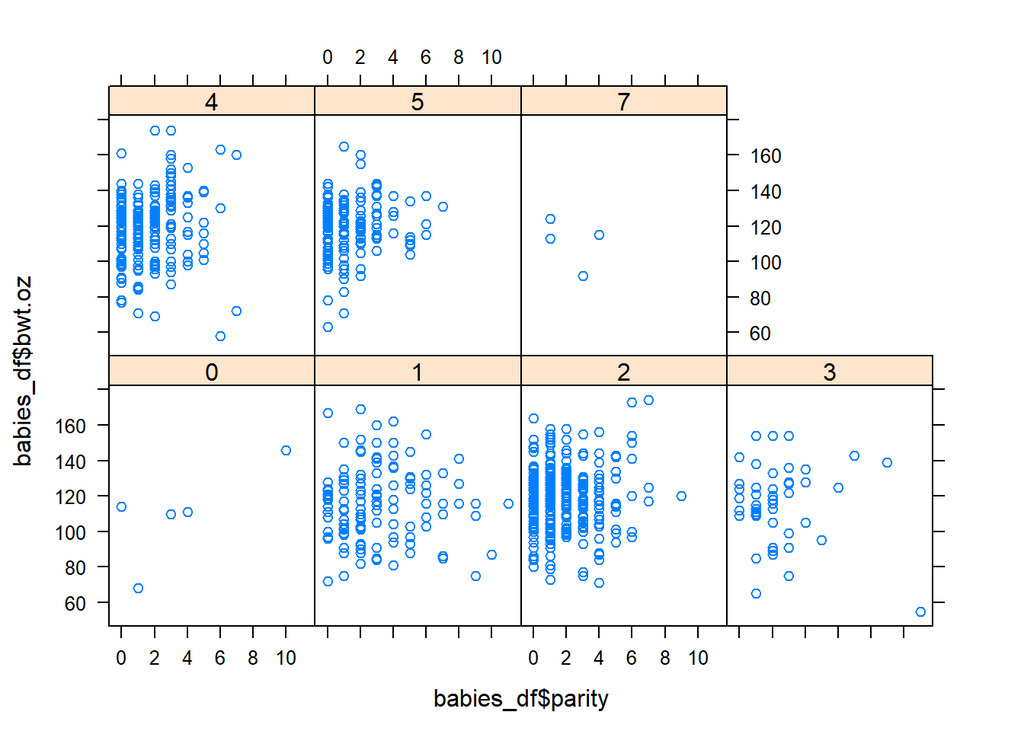

```r
xyplot(babies_df$bwt.oz~babies_df$parity | as.factor(babies_df$med))
```

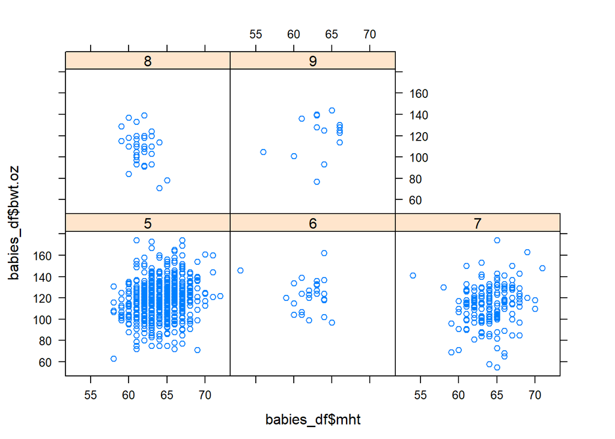

```r
xyplot(babies_df$bwt.oz~babies_df$mht | as.factor(babies_df$mrace))
```

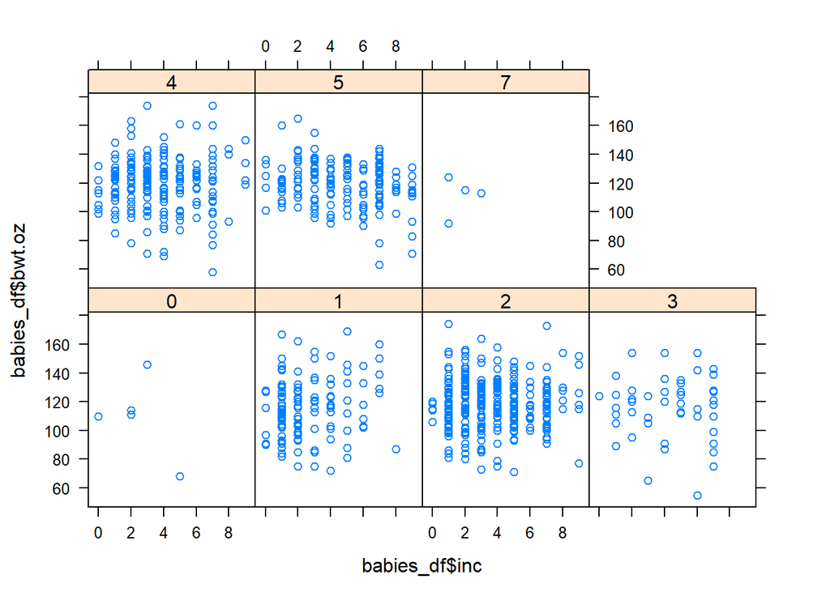

```r
xyplot(babies_df$bwt.oz~babies_df$inc | as.factor(babies_df$med))
```

Most of the inteteraction plots(xy and bw plots) does not show major signs of interaction. However, there seems to be interaction between the income and mother’s education. We can use this intercation in our linear model to see if helps improve our r^2.

Lets create linear models:

First let’s mean center noncategorical variable so that interpreation becomes easier.

```r
babies_df$parity = babies_df$parity - mean(babies_df$parity)

babies_df$mage = babies_df$mage - mean(babies_df$mage)

babies_df$mht = babies_df$mht - mean(babies_df$mht)

babies_df$mpregwt = babies_df$mpregwt - mean(babies_df$mpregwt)
```

Let’s create a linear model by taking smoke, parity, age, mothers height, preg wt, mother race, mother education and income.

```r
babies.lm = lm(bwt.oz~ as.factor(smoke) + parity + mage + mht + mpregwt + as.factor(mrace) + as.factor(med) + as.factor(inc),  data=babies_df)

summary(babies.lm)
```

```
##
## Call:
## lm(formula = bwt.oz ~ as.factor(smoke) + parity + mage + mht +
##     mpregwt + as.factor(mrace) + as.factor(med) + as.factor(inc),
##     data = babies_df)
##
## Residuals:
##     Min      1Q  Median      3Q     Max
## -66.464  -9.676  -0.334  10.373  49.055
##
## Coefficients:
##                    Estimate Std. Error t value Pr(>|t|)
## (Intercept)       114.31955    8.09632  14.120  < 2e-16 ***
## as.factor(smoke)1  -9.23517    1.18005  -7.826 1.50e-14 ***
## parity              0.78187    0.40086   1.950 0.051453 .
## mage               -0.02705    0.13430  -0.201 0.840418
## mht                 0.94625    0.26971   3.508 0.000475 ***
## mpregwt             0.10879    0.03297   3.300 0.001007 **
## as.factor(mrace)6   4.19494    3.53092   1.188 0.235144
## as.factor(mrace)7  -9.14155    1.59240  -5.741 1.31e-08 ***
## as.factor(mrace)8  -7.65440    3.12337  -2.451 0.014460 *
## as.factor(mrace)9  -2.68980    4.44035  -0.606 0.544836
## as.factor(med)1     5.96206    7.80927   0.763 0.445403
## as.factor(med)2     8.06224    7.70613   1.046 0.295763
## as.factor(med)3     6.06152    8.00269   0.757 0.449000
## as.factor(med)4     8.51416    7.75189   1.098 0.272372
## as.factor(med)5     7.55992    7.78403   0.971 0.331723
## as.factor(med)7    -4.37963   11.32919  -0.387 0.699165
## as.factor(inc)1     3.43894    3.59253   0.957 0.338717
## as.factor(inc)2     5.22012    3.60482   1.448 0.147961
## as.factor(inc)3     2.13366    3.64001   0.586 0.557918
## as.factor(inc)4     2.76108    3.72187   0.742 0.458384
## as.factor(inc)5     2.17449    3.76549   0.577 0.563770
## as.factor(inc)6     1.22521    4.03056   0.304 0.761217
## as.factor(inc)7     2.14669    3.73493   0.575 0.565607
## as.factor(inc)8     3.30223    5.43759   0.607 0.543817
## as.factor(inc)9    -1.40629    5.07369  -0.277 0.781715
## ---
## Signif. codes:  0 '***' 0.001 '**' 0.01 '*' 0.05 '.' 0.1 ' ' 1
##
## Residual standard error: 16.75 on 844 degrees of freedom
## Multiple R-squared:  0.1624, Adjusted R-squared:  0.1386
## F-statistic: 6.818 on 24 and 844 DF,  p-value: < 2.2e-16
```

We can see that we got r^2 of 0.1624, which is quite low and standard error is 16.75.

Taking different transformation such as log, quadratic and other transformation for diffrent variable did not seem to improve the r^2.

Also, tried creating linear model by taking diffrent interacation. The best r^2 I got is for the interaction between income and mother’s education (which we also saw earlier in the interaction plot).

```r
babies.lm2 = lm(bwt.oz~ as.factor(smoke) + parity + mage + mht + mpregwt + as.factor(mrace) + as.factor(inc)*as.factor(med),  data=babies_df)

summary(babies.lm2)
```

```
##
## Call:
## lm(formula = bwt.oz ~ as.factor(smoke) + parity + mage + mht +
##     mpregwt + as.factor(mrace) + as.factor(inc) * as.factor(med),
##     data = babies_df)
##
## Residuals:
##     Min      1Q  Median      3Q     Max
## -66.973  -9.451   0.000   9.616  50.883
##
## Coefficients: (16 not defined because of singularities)
##                                  Estimate Std. Error t value Pr(>|t|)
## (Intercept)                     107.01700   16.64758   6.428 2.21e-10 ***
## as.factor(smoke)1                -9.68104    1.19873  -8.076 2.43e-15 ***
## parity                            0.70278    0.41530   1.692 0.090990 .
## mage                             -0.04472    0.13682  -0.327 0.743883
## mht                               1.07347    0.27740   3.870 0.000118 ***
## mpregwt                           0.10802    0.03359   3.216 0.001350 **
## as.factor(mrace)6                 3.30290    3.60865   0.915 0.360322
## as.factor(mrace)7                -8.16173    1.62579  -5.020 6.36e-07 ***
## as.factor(mrace)8                -7.64759    3.16139  -2.419 0.015781 *
## as.factor(mrace)9                -2.32944    4.50277  -0.517 0.605064
## as.factor(inc)1                  52.96336   32.01014   1.655 0.098399 .
## as.factor(inc)2                  12.14805   20.34901   0.597 0.550685
## as.factor(inc)3                  54.10766   24.14333   2.241 0.025291 *
## as.factor(inc)4                  -6.20718    8.46978  -0.733 0.463856
## as.factor(inc)5                 -24.58382   23.54247  -1.044 0.296691
## as.factor(inc)6                 -15.21785    8.64572  -1.760 0.078760 .
## as.factor(inc)7                  -7.60390    8.00578  -0.950 0.342498
## as.factor(inc)8                  -9.91333    9.79228  -1.012 0.311669
## as.factor(inc)9                 -20.26363    9.04527  -2.240 0.025347 *
## as.factor(med)1                  11.50184   18.08623   0.636 0.524993
## as.factor(med)2                  10.43042   18.03713   0.578 0.563240
## as.factor(med)3                  25.51563   23.58399   1.082 0.279619
## as.factor(med)4                  12.97202   17.81854   0.728 0.466821
## as.factor(med)5                  24.69607   18.29287   1.350 0.177383
## as.factor(med)7                 -46.85048   24.13909  -1.941 0.052624 .
## as.factor(inc)1:as.factor(med)1 -46.76493   32.74743  -1.428 0.153665
## as.factor(inc)2:as.factor(med)1 -10.67125   21.69484  -0.492 0.622938
## as.factor(inc)3:as.factor(med)1 -52.96044   25.45813  -2.080 0.037814 *
```

[output cut: 42 more lines]

```
## as.factor(inc)1:as.factor(med)7        NA         NA      NA       NA
## as.factor(inc)2:as.factor(med)7  43.24555   31.79172   1.360 0.174122
## as.factor(inc)3:as.factor(med)7        NA         NA      NA       NA
## as.factor(inc)4:as.factor(med)7        NA         NA      NA       NA
## as.factor(inc)5:as.factor(med)7        NA         NA      NA       NA
## as.factor(inc)6:as.factor(med)7        NA         NA      NA       NA
## as.factor(inc)7:as.factor(med)7        NA         NA      NA       NA
## as.factor(inc)8:as.factor(med)7        NA         NA      NA       NA
## as.factor(inc)9:as.factor(med)7        NA         NA      NA       NA
## ---
## Signif. codes:  0 '***' 0.001 '**' 0.01 '*' 0.05 '.' 0.1 ' ' 1
##
## Residual standard error: 16.56 on 806 degrees of freedom
## Multiple R-squared:  0.2187, Adjusted R-squared:  0.1586
## F-statistic: 3.639 on 62 and 806 DF,  p-value: < 2.2e-16
```

```r
confint(babies.lm2)
```

```
##                                         2.5 %      97.5 %
## (Intercept)                       74.33927515 139.6947186
## as.factor(smoke)1                -12.03403649  -7.3280467
## parity                            -0.11241736   1.5179740
## mage                              -0.31329105   0.2238553
## mht                                0.52896746   1.6179747
## mpregwt                            0.04209809   0.1739517
## as.factor(mrace)6                 -3.78056217  10.3863635
## as.factor(mrace)7                -11.35301967  -4.9704395
## as.factor(mrace)8                -13.85311622  -1.4420580
## as.factor(mrace)9                -11.16798569   6.5090981
## as.factor(inc)1                   -9.86972000 115.7964312
## as.factor(inc)2                  -27.79525318  52.0913580
## as.factor(inc)3                    6.71644198 101.4988805
## as.factor(inc)4                  -22.83260327  10.4182450
## as.factor(inc)5                  -70.79561027  21.6279634
## as.factor(inc)6                  -32.18863506   1.7529259
## as.factor(inc)7                  -23.31854089   8.1107380
## as.factor(inc)8                  -29.13471034   9.3080448
## as.factor(inc)9                  -38.01870571  -2.5085638
## as.factor(med)1                  -23.99982169  47.0035043
## as.factor(med)2                  -24.97486390  45.8357020
## as.factor(med)3                  -20.77766587  71.8089271
## as.factor(med)4                  -22.00420017  47.9482416
## as.factor(med)5                  -11.21121880  60.6033652
## as.factor(med)7                  -94.23337886   0.5324111
## as.factor(inc)1:as.factor(med)1 -111.04523168  17.5153761
## as.factor(inc)2:as.factor(med)1  -53.25630003  31.9137916
## as.factor(inc)3:as.factor(med)1 -102.93250310  -2.9883703
## as.factor(inc)4:as.factor(med)1  -12.14148996  33.5070731
## as.factor(inc)5:as.factor(med)1  -15.78282596  83.0678495
## as.factor(inc)6:as.factor(med)1   -2.47715333  48.3129827
## as.factor(inc)7:as.factor(med)1   12.84823826  63.2726648
## as.factor(inc)8:as.factor(med)1  -58.67026158  22.0511955
## as.factor(inc)9:as.factor(med)1            NA          NA
## as.factor(inc)1:as.factor(med)2 -108.59566576  19.8418171
## as.factor(inc)2:as.factor(med)2  -43.42488335  41.2164393
## as.factor(inc)3:as.factor(med)2  -96.93309998   1.8831033
## as.factor(inc)4:as.factor(med)2   -5.82451004  38.0915886
## as.factor(inc)5:as.factor(med)2  -18.87653362  77.9864089
```

[output cut: 25 more lines]

```
## as.factor(inc)4:as.factor(med)5            NA          NA
## as.factor(inc)5:as.factor(med)5  -28.82137940  69.5286367
## as.factor(inc)6:as.factor(med)5            NA          NA
## as.factor(inc)7:as.factor(med)5            NA          NA
## as.factor(inc)8:as.factor(med)5            NA          NA
## as.factor(inc)9:as.factor(med)5            NA          NA
## as.factor(inc)1:as.factor(med)7            NA          NA
## as.factor(inc)2:as.factor(med)7  -19.15877465 105.6498784
## as.factor(inc)3:as.factor(med)7            NA          NA
## as.factor(inc)4:as.factor(med)7            NA          NA
## as.factor(inc)5:as.factor(med)7            NA          NA
## as.factor(inc)6:as.factor(med)7            NA          NA
## as.factor(inc)7:as.factor(med)7            NA          NA
## as.factor(inc)8:as.factor(med)7            NA          NA
## as.factor(inc)9:as.factor(med)7            NA          NA
```

We can see that the r^2 has increased to 0.2187 and the standard error is 16.56.

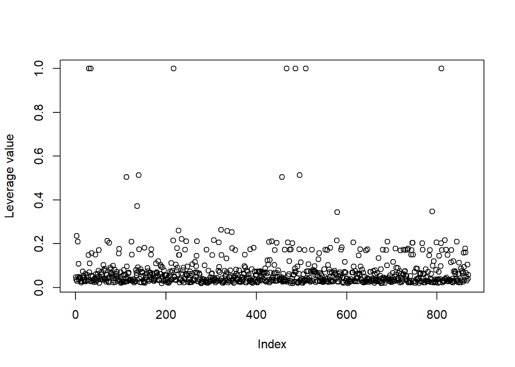

```r
lev = hatvalues(babies.lm2)
cooks = cooks.distance(babies.lm2)

plot(lev, ylab = "Leverage value")
```

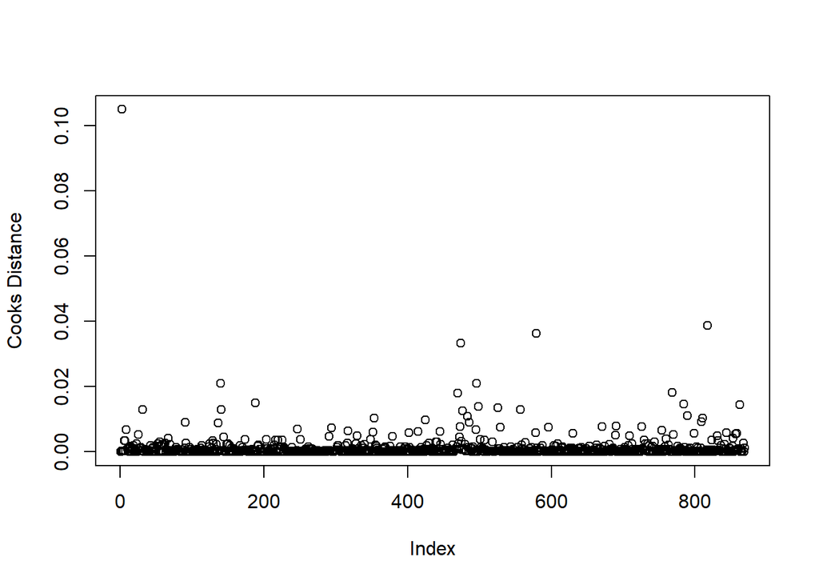

```r
plot(cooks, ylab = "Cooks Distance")
```

To check if smoking tends to lowers babies weight, we can perform nested F test.

Nested F test:

model1: linear model by taking smoke, parity, age, mothers height, preg wt, mother race, mother education and income and interaction between income and education

model2:linear model by taking parity, age, mothers height, preg wt, mother race, mother education and income and interaction between income and education (not including smoking).

```r
babies.lm2_nosmoking = lm(bwt.oz~ parity + mage + mht + mpregwt + as.factor(mrace) + as.factor(inc)*as.factor(med) + as.factor(inc)* as.factor(med),  data=babies_df)
```

```r
anova(babies.lm2,babies.lm2_nosmoking)
```

```
## Analysis of Variance Table
##
## Model 1: bwt.oz ~ as.factor(smoke) + parity + mage + mht + mpregwt + as.factor(mrace) +
##     as.factor(inc) * as.factor(med)
## Model 2: bwt.oz ~ parity + mage + mht + mpregwt + as.factor(mrace) + as.factor(inc) *
##     as.factor(med) + as.factor(inc) * as.factor(med)
##   Res.Df    RSS Df Sum of Sq      F    Pr(>F)
## 1    806 220962
## 2    807 238843 -1    -17881 65.223 2.432e-15 ***
## ---
## Signif. codes:  0 '***' 0.001 '**' 0.01 '*' 0.05 '.' 0.1 ' ' 1
```

We can see that the F statics is 65.223 and p value is 2.432e^-15. Since the p value is very small, we can conclude that based on the data, smoking indeed affects the baby weight.

Let’s perform t test to calculate the likely range for the difference in birth weights for smokers and non-smokers

```r
t.test(babies_df$bwt.oz~babies_df$smoke, data= babies_df)
```

```
##
##  Welch Two Sample t-test
##
## data:  babies_df$bwt.oz by babies_df$smoke
## t = 7.5415, df = 833.24, p-value = 1.215e-13
## alternative hypothesis: true difference in means is not equal to 0
## 95 percent confidence interval:
##   6.665042 11.355139
## sample estimates:
## mean in group 0 mean in group 1
##        122.5386        113.5285
```

Based on the t-test we can see that the 95% confidence interval for the difference in birth weights for smokers and non-smokers is between 6.665 and 11.3551. We can also notice that the confidence interval does not include 0.

Check if smoking and birth weight differs by mother’s race

Lets plot how the interaction between baby’s weight and smoking differs by mothers race.

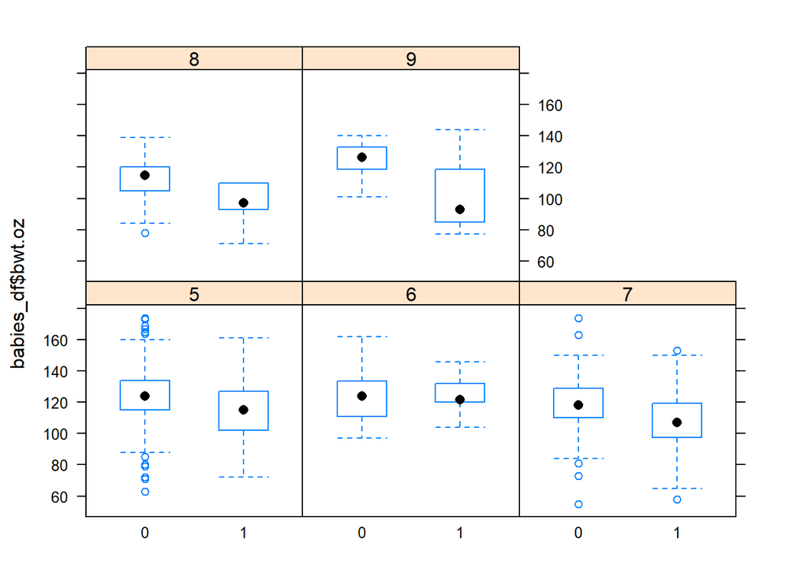

```r
bwplot(babies_df$bwt.oz~as.factor(babies_df$smoke) | as.factor(babies_df$mrace))
```

We can do this by perform a nested F test

```r
babies.lm3 = lm(bwt.oz~ as.factor(smoke) + parity + mage + mht + mpregwt + as.factor(mrace) + as.factor(inc)*as.factor(med) + as.factor(smoke)*as.factor(mrace),  data=babies_df)
```

```r
anova(babies.lm2,babies.lm3)
```

```
## Analysis of Variance Table
##
## Model 1: bwt.oz ~ as.factor(smoke) + parity + mage + mht + mpregwt + as.factor(mrace) +
##     as.factor(inc) * as.factor(med)
## Model 2: bwt.oz ~ as.factor(smoke) + parity + mage + mht + mpregwt + as.factor(mrace) +
##     as.factor(inc) * as.factor(med) + as.factor(smoke) * as.factor(mrace)
##   Res.Df    RSS Df Sum of Sq      F Pr(>F)
## 1    806 220962
## 2    802 219781  4    1180.8 1.0772 0.3666
```

Based on the nested F test the F statistic is 1.0772 and p value is 0.3666. Since, p value is high we can conclude that the association between mother’s race and smoking is not significant on baby’s weight.

Lets again look at our final model:

```r
summary(babies.lm2)
```

```
##
## Call:
## lm(formula = bwt.oz ~ as.factor(smoke) + parity + mage + mht +
##     mpregwt + as.factor(mrace) + as.factor(inc) * as.factor(med),
##     data = babies_df)
##
## Residuals:
##     Min      1Q  Median      3Q     Max
## -66.973  -9.451   0.000   9.616  50.883
##
## Coefficients: (16 not defined because of singularities)
##                                  Estimate Std. Error t value Pr(>|t|)
## (Intercept)                     107.01700   16.64758   6.428 2.21e-10 ***
## as.factor(smoke)1                -9.68104    1.19873  -8.076 2.43e-15 ***
## parity                            0.70278    0.41530   1.692 0.090990 .
## mage                             -0.04472    0.13682  -0.327 0.743883
## mht                               1.07347    0.27740   3.870 0.000118 ***
## mpregwt                           0.10802    0.03359   3.216 0.001350 **
## as.factor(mrace)6                 3.30290    3.60865   0.915 0.360322
## as.factor(mrace)7                -8.16173    1.62579  -5.020 6.36e-07 ***
## as.factor(mrace)8                -7.64759    3.16139  -2.419 0.015781 *
## as.factor(mrace)9                -2.32944    4.50277  -0.517 0.605064
## as.factor(inc)1                  52.96336   32.01014   1.655 0.098399 .
## as.factor(inc)2                  12.14805   20.34901   0.597 0.550685
## as.factor(inc)3                  54.10766   24.14333   2.241 0.025291 *
## as.factor(inc)4                  -6.20718    8.46978  -0.733 0.463856
## as.factor(inc)5                 -24.58382   23.54247  -1.044 0.296691
## as.factor(inc)6                 -15.21785    8.64572  -1.760 0.078760 .
## as.factor(inc)7                  -7.60390    8.00578  -0.950 0.342498
## as.factor(inc)8                  -9.91333    9.79228  -1.012 0.311669
## as.factor(inc)9                 -20.26363    9.04527  -2.240 0.025347 *
## as.factor(med)1                  11.50184   18.08623   0.636 0.524993
## as.factor(med)2                  10.43042   18.03713   0.578 0.563240
## as.factor(med)3                  25.51563   23.58399   1.082 0.279619
## as.factor(med)4                  12.97202   17.81854   0.728 0.466821
## as.factor(med)5                  24.69607   18.29287   1.350 0.177383
## as.factor(med)7                 -46.85048   24.13909  -1.941 0.052624 .
## as.factor(inc)1:as.factor(med)1 -46.76493   32.74743  -1.428 0.153665
## as.factor(inc)2:as.factor(med)1 -10.67125   21.69484  -0.492 0.622938
## as.factor(inc)3:as.factor(med)1 -52.96044   25.45813  -2.080 0.037814 *
```

[output cut: 42 more lines]

```
## as.factor(inc)1:as.factor(med)7        NA         NA      NA       NA
## as.factor(inc)2:as.factor(med)7  43.24555   31.79172   1.360 0.174122
## as.factor(inc)3:as.factor(med)7        NA         NA      NA       NA
## as.factor(inc)4:as.factor(med)7        NA         NA      NA       NA
## as.factor(inc)5:as.factor(med)7        NA         NA      NA       NA
## as.factor(inc)6:as.factor(med)7        NA         NA      NA       NA
## as.factor(inc)7:as.factor(med)7        NA         NA      NA       NA
## as.factor(inc)8:as.factor(med)7        NA         NA      NA       NA
## as.factor(inc)9:as.factor(med)7        NA         NA      NA       NA
## ---
## Signif. codes:  0 '***' 0.001 '**' 0.01 '*' 0.05 '.' 0.1 ' ' 1
##
## Residual standard error: 16.56 on 806 degrees of freedom
## Multiple R-squared:  0.2187, Adjusted R-squared:  0.1586
## F-statistic: 3.639 on 62 and 806 DF,  p-value: < 2.2e-16
```

```r
confint(babies.lm2)
```

```
##                                         2.5 %      97.5 %
## (Intercept)                       74.33927515 139.6947186
## as.factor(smoke)1                -12.03403649  -7.3280467
## parity                            -0.11241736   1.5179740
## mage                              -0.31329105   0.2238553
## mht                                0.52896746   1.6179747
## mpregwt                            0.04209809   0.1739517
## as.factor(mrace)6                 -3.78056217  10.3863635
## as.factor(mrace)7                -11.35301967  -4.9704395
## as.factor(mrace)8                -13.85311622  -1.4420580
## as.factor(mrace)9                -11.16798569   6.5090981
## as.factor(inc)1                   -9.86972000 115.7964312
## as.factor(inc)2                  -27.79525318  52.0913580
## as.factor(inc)3                    6.71644198 101.4988805
## as.factor(inc)4                  -22.83260327  10.4182450
## as.factor(inc)5                  -70.79561027  21.6279634
## as.factor(inc)6                  -32.18863506   1.7529259
## as.factor(inc)7                  -23.31854089   8.1107380
## as.factor(inc)8                  -29.13471034   9.3080448
## as.factor(inc)9                  -38.01870571  -2.5085638
## as.factor(med)1                  -23.99982169  47.0035043
## as.factor(med)2                  -24.97486390  45.8357020
## as.factor(med)3                  -20.77766587  71.8089271
## as.factor(med)4                  -22.00420017  47.9482416
## as.factor(med)5                  -11.21121880  60.6033652
## as.factor(med)7                  -94.23337886   0.5324111
## as.factor(inc)1:as.factor(med)1 -111.04523168  17.5153761
## as.factor(inc)2:as.factor(med)1  -53.25630003  31.9137916
## as.factor(inc)3:as.factor(med)1 -102.93250310  -2.9883703
## as.factor(inc)4:as.factor(med)1  -12.14148996  33.5070731
## as.factor(inc)5:as.factor(med)1  -15.78282596  83.0678495
## as.factor(inc)6:as.factor(med)1   -2.47715333  48.3129827
## as.factor(inc)7:as.factor(med)1   12.84823826  63.2726648
## as.factor(inc)8:as.factor(med)1  -58.67026158  22.0511955
## as.factor(inc)9:as.factor(med)1            NA          NA
## as.factor(inc)1:as.factor(med)2 -108.59566576  19.8418171
## as.factor(inc)2:as.factor(med)2  -43.42488335  41.2164393
## as.factor(inc)3:as.factor(med)2  -96.93309998   1.8831033
## as.factor(inc)4:as.factor(med)2   -5.82451004  38.0915886
## as.factor(inc)5:as.factor(med)2  -18.87653362  77.9864089
```

[output cut: 25 more lines]

```
## as.factor(inc)4:as.factor(med)5            NA          NA
## as.factor(inc)5:as.factor(med)5  -28.82137940  69.5286367
## as.factor(inc)6:as.factor(med)5            NA          NA
## as.factor(inc)7:as.factor(med)5            NA          NA
## as.factor(inc)8:as.factor(med)5            NA          NA
## as.factor(inc)9:as.factor(med)5            NA          NA
## as.factor(inc)1:as.factor(med)7            NA          NA
## as.factor(inc)2:as.factor(med)7  -19.15877465 105.6498784
## as.factor(inc)3:as.factor(med)7            NA          NA
## as.factor(inc)4:as.factor(med)7            NA          NA
## as.factor(inc)5:as.factor(med)7            NA          NA
## as.factor(inc)6:as.factor(med)7            NA          NA
## as.factor(inc)7:as.factor(med)7            NA          NA
## as.factor(inc)8:as.factor(med)7            NA          NA
## as.factor(inc)9:as.factor(med)7            NA          NA
```

Interesting associations with birth weight:

The avg value of baby weight for a white mother with avg values of parity, height, preg weight, age and whose education is less than 8th grade and income under 2500 and who does not smoke is 107.017

Keeping all other factor constant, if the mother smokes then the multiplicative factor associated with the baby weight is -9.68 [CI is between -12.03403649 and -7.3280467]

Keeping all other factor constant, if the parity changes by one unit then the multiplicative factor associated with the baby weight is 0.7027 [CI is between -0.11241736 and 1.5179740]

Keeping all other factor constant, if the mother’s height changes by one unit then the multiplicative factor associated with the baby weight is 1.07347 [CI is between 0.52896746 and 1.6179747]

Keeping all other factor constant, if the mother’s race changes from white to mexian then the multiplicative factor associated with the baby weight is 3.30290 [CI is between -3.78056217 and 10.3863635]

Keeping all other factor constant, if the mother’s race changes from white to black then the multiplicative factor associated with the baby weight is -8.16173 [CI is between -11.35301967 and -4.9704395]

Keeping all other factor constant, if the mother’s race changes from white to asian then the multiplicative factor associated with the baby weight is -7.64759 [CI is between -13.85311622 and -1.4420580

Keeping all other factor constant, if the mother’s race changes from white to mix then the multiplicative factor associated with the baby weight is -2.32944 [CI is between -11.16798569 and 6.5090981]